# Diversification in the Managed Futures Universe

Derek G. Nokes, CUNY

Friday, May 22, 2015

[output not shown]

### Portfolio Return Confidence Intervals:

Using our definition of portfolio return variability we can define the expected negative fluctuation (i.e., loss) at a given confidence interval as:

$VaR = -\alpha_{CL}\sigma_{P,M}$

Where

$\alpha_{CL}$ is the critical value at the confidence level $CL$

$\sigma_{P,M}$ is the standard deviation of the portfolio returns over the time interval $m=1, \dots, M$

This simple parametric model can be extended in a myriad of ways to account for the established stylized facts pertaining to the statistical characteristics of investment returns. In particular, our factor-based model can be combined with any choice for the the marginal distribution of component returns, copulas can be used to include more extreme returns in the joint distribution of returns, and returns can be standardized with forecasts of the time-varying moments about the distribution. In this paper, we use on the simplest possible model for the expected return distribution so that we may focus specifically on the factor model.

## Too Many Moving Parts

The number of independent parameters $P$ in a covariance matrix grows with the number of investments $I$ according to the following function:

$P=\frac{I\left(I+1\right)}{2}$

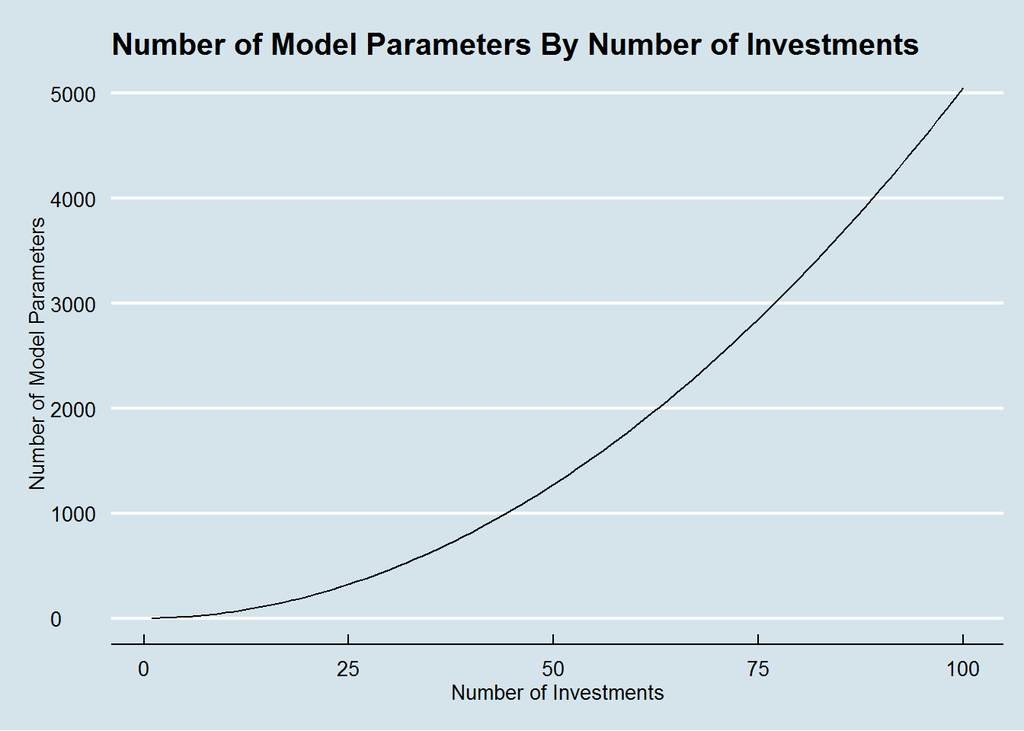

The number of independent parameters to be estimated in the covariance matrix grows with the square of the number of investments, while the number of data points available to estimate a covariance matrix grows only linearly with the number of investments. In other words, the larger the portfolio, the more historical data we typically need to estimate the covariance matrix reliably. This is particularly problematic when our interest is in the temporal evolution of the relationships between investments in the portfolio.

In this paper, we extract the manager, program, and monthly return data for the subset of the managed futures investment universe tracked on the Altergris website. We conduct some limited exploratory data analysis and clean the data to be used in our modeling. We create a statistical factor model using principal component analysis (PCA), then use our statistical factor model to group and interpret the relationships between available programs in the managed futures investment universe. Finally, we compute sensitivities linking the portfolio volatility of a hypothetical set of managed futures investments to changes in the importance of different factors. The sensitivities provide a powerful analytical framework to be used to understand portfolio return variation in terms of a few independent factors.

# Data

In this section we provide detailed information about the acquisition of the data for this paper. A brief overview of the available data is provided below. It is important to note that much of the data collected was ultimately not cleaned and used in our modeling. Data in the database has not been normalized as this application is not transaction-oriented and storage has been set up for a one-time analysis.

Although return data quality appears high, the quality of data pertaining to manager and program information is much lower. This data set will likely be cleaned and used for future research projects. The entire system for collecting and storing the data is included below.

## Raw Data Extraction, Transformation, and Loading (ETL)

We extract the raw manager, program, and monthly return data to pipe-delimited flat files using some custom R functions made considerably simpler through the use of the ‘rvest’ and ‘lubridate’ packages.

for each managed futures program on the Altergis website we extract the following types of information:

– CTA Name

```r
extractCtaName<-function (programHtmlSession){
  # extract the CTA name
  ctaName <- programHtmlSession %>% html() %>%
    html_nodes("#spnHeadingPP1") %>% html_text()
  # remove foreign language characters
  ctaName
}
```

– Program Name

```r
extractProgramName<-function (programHtmlSession){
  # extract the program name
  programName <- programHtmlSession %>% html() %>%
    html_nodes("#spnHeadingPP2") %>% html_text()
  # remove foreign language characters
  programName
}
```

– Monthly Returns

```r
extractMonthlyReturns<-function (programHtmlSession,programId){
  # extract CTA Name
  ctaName<-extractCtaName(programHtmlSession)
  # extract the program name
  programName<-extractProgramName(programHtmlSession)
  # extract the monthly returns
  a<-html_table(html_nodes(programHtmlSession, "table")[[1]],fill=TRUE)
  # extract the years
  YYYY<-as.numeric(a$X1[3:(length(a$X1)-1)])
  # find the number of years
  nYears<-length(YYYY)
  # create the empty end of month date matrix
  dates<-matrix(data=NA,nrow=nYears,ncol=12)
  # find the last day of each month
  for (yyyyIndex in seq_along(YYYY)){
    yyyy<-YYYY[yyyyIndex]
    # find the last day for the current year
    eomDates<-ceiling_date(ISOdate(yyyy,1,1,0,0,0,tz='EST') +
                             months(1:12))-days(1)
    # store the end of month dates
    dates[yyyyIndex,1:12]<-format(eomDates, '%Y-%m-%d')
  }
  # flatten the end of month matrix
  eomDates<-matrix(dates,nrow=nYears*12,1)
  # extract the returns
  jan<-as.numeric(a$X2[!is.na(sub('Jan',NA,a$X2))])
  feb<-as.numeric(a$X3[!is.na(sub('Feb',NA,a$X3))])
  mar<-as.numeric(a$X4[!is.na(sub('Mar',NA,a$X4))])
  apr<-as.numeric(a$X5[!is.na(sub('Apr',NA,a$X5))])
  may<-as.numeric(a$X6[!is.na(sub('May',NA,a$X6))])
  jun<-as.numeric(a$X7[!is.na(sub('Jun',NA,a$X7))])
  jul<-as.numeric(a$X8[!is.na(sub('Jul',NA,a$X8))])
  aug<-as.numeric(a$X9[!is.na(sub('Aug',NA,a$X9))])
  sep<-as.numeric(a$X10[!is.na(sub('Sep',NA,a$X10))])
  oct<-as.numeric(a$X11[!is.na(sub('Oct',NA,a$X11))])
  nov<-as.numeric(a$X12[!is.na(sub('Nov',NA,a$X12))])
  dec<-as.numeric(a$X13[!is.na(sub('Dec',NA,a$X13))])
  # create the monthly return data frame
  monthlyReturns<-cbind(ctaName,programName,yyyy,jan,feb,mar,
    apr,may,jun,jul,aug,sep,oct,nov,dec)
  # create the monthly return matrix by year
  monthlyReturnsMatrix<-as.matrix(cbind(jan,feb,mar,apr,
    may,jun,jul,aug,sep,oct,nov,dec))
  # find the dimension of the monthly returns matrix
  dimension<-dim(monthlyReturnsMatrix)
  # flatten the monthly return matrix
  monthlyReturnsData<-matrix(monthlyReturnsMatrix,dimension[1]*dimension[2],1)
  # create the data frame
  data<-data.frame(dates=eomDates,monthlyReturns=monthlyReturnsData,
    stringsAsFactors=FALSE)
  # get the sort index
  sortIndex<-sort(data[,1],index.return=TRUE)
  # order the data
  data<-data[sortIndex$ix,]
  # add the CTA Name
  data['ctaName']<-ctaName
  # add the program name
  data['programName']<-programName
  # add the program ID
  data['programId']<-programId
  # find the NAs
  naIndex<-is.na(data[,2])
  # return the data
  data[!naIndex,]
}
```

– Manager Address

```r
extractAddress<-function (programHtmlSession,ctaName,programName){
  # extract the address
  address<-html_table(html_nodes(programHtmlSession,
    "table")[[10]],fill=TRUE)
  # extract the address
  addressHeader<-t(address[1])
  # remove the colons
  addressHeader<-sub(':','',addressHeader[2:7])
  addressData<-t(address[2])
  # remove new line characters
  addressData<-sub('\n','-',addressData[2:7])
  # create address data frame
  address<-data.frame(cbind(addressHeader,addressData))
  colnames(address)<-c('column','value')
  address['columnType']<-'address'
  address
}
```

– Investment Methodology

```r
extractInvestmentMethodology<-function (programHtmlSession,ctaName,programName){
  # extract the investment methodlogy
  investmentMethodology<-html_table(html_nodes(programHtmlSession,
    "table")[[14]])
  investmentMethodologyHeader<-t(investmentMethodology[1])
  investmentMethodologyData<-t(investmentMethodology[2])
  colnames(investmentMethodology)<-c('column','value')
  investmentMethodology['columnType']<-'investmentMethodology'
  investmentMethodology
}
```

– Instruments Traded

```r
extractInstruments<-function (programHtmlSession,ctaName,programName){
  # extract the instruments
  instruments<-html_table(html_nodes(programHtmlSession,
    "table")[[15]])
  colnames(instruments)<-c('column','value')
  instruments['columnType']<-'instruments'
  instruments
}
```

– Sectors of Instruments Traded

```r
# extract program data
extractSectors<-function (programHtmlSession,ctaName,programName){
  # extract sector information
  sectors<-html_table(html_nodes(programHtmlSession,
    "table")[[13]])
  # extract sector information
  colnames(sectors)<-c('column','value')
  sectors['columnType']<-'sectors'
  sectors
}
```

– Geographical Focus of Instruments Traded

```r
extractGeographicalFocus<-function (programHtmlSession){
  # extract the geographical focus
  geographicalFocus<-html_table(html_nodes(programHtmlSession,
    "table")[[16]])
  # extract the geographical focus
  colnames(geographicalFocus)<-c('column','value')
  geographicalFocus['columnType']<-'geographicalFocus'
  geographicalFocus
}
```

– Holding Periods (Short/Medium/Long)

```r
extractHoldingPeriod<-function (programHtmlSession){
  # extract the holding period
  holdingPeriod<-html_table(html_nodes(programHtmlSession,
    "table")[[17]])
  colnames(holdingPeriod)<-c('column','value')
  holdingPeriod['columnType']<-'holdingPeriod'
  holdingPeriod
}
```

– Investment Terms and Information

```r
extractInvestmentTermsAndInfo<-function (programHtmlSession){
  # extract the investment terms and info
  investmentTermsAndInfo<-html_table(html_nodes(programHtmlSession,
    "table")[[18]])
  investmentTermsAndInfo[,2]<-NULL
  colnames(investmentTermsAndInfo)<-c('column','value')
  investmentTermsAndInfo['columnType']<-'investmentTermsAndInfo'
  investmentTermsAndInfo
}
```

We extract manager, program, and month return data for a single CTA program with a function that calls functions for each sub-type.

```r
# extract program data
extractProgramInfo<-function (programHtmlSession,programId){
  # create the program session
  # extract the CTA name
  ctaName<-extractCtaName(programHtmlSession)
  # extract the program name
  programName<-extractProgramName(programHtmlSession)
  # extract the address data into a data frame
  address<-extractAddress(programHtmlSession)
  # extract the investment methodology data into a data frame
  investmentMethodology<-extractInvestmentMethodology(programHtmlSession)
  # extract the instruments data into a data frame
  instruments<-extractInstruments(programHtmlSession)
  # extract the sector data into a data frame
  sectors<-extractSectors(programHtmlSession)
  # extract the geographical focus data into a data frame
  geographicalFocus<-extractGeographicalFocus(programHtmlSession)
  # extract the holding period data into a data frame
  holdingPeriod<-extractHoldingPeriod(programHtmlSession)
  # extract the investment terms and info data into a data frame
  investmentTermsAndInfo<-extractInvestmentTermsAndInfo(programHtmlSession)
  # bind all of the data frames together
  programInfo<-data.frame(rbind(address,
    investmentMethodology,instruments,sectors,geographicalFocus,
    holdingPeriod,investmentTermsAndInfo),stringsAsFactors=FALSE)
  # add the program CTA name
  programInfo['ctaName']<-ctaName
  # add the program name
  programInfo['programName']<-programName
  # add the program ID
  programInfo['programId']<-programId
  # return the data
  programInfo
}

cleanProgramInfo<-function (programInfo){
  # clean program info

  # remove the \r\n newlines
  programInfo <- as.data.frame(lapply(programInfo,
    function(x) if(is.character(x)|is.factor(x)) gsub("\r\n","",x) else x),
    stringsAsFactors=FALSE)
  # remove the % signs
  programInfo <- as.data.frame(lapply(programInfo,
    function(x) if(is.character(x)|is.factor(x)) gsub("%","",x) else x),
    stringsAsFactors=FALSE)
  # remove the commas
  programInfo <- as.data.frame(lapply(programInfo,
    function(x) if(is.character(x)|is.factor(x)) gsub(",","",x) else x),
    stringsAsFactors=FALSE)
  # remove the colons
  programInfo <- as.data.frame(lapply(programInfo,
    function(x) if(is.character(x)|is.factor(x)) gsub("[:]","",x) else x),
    stringsAsFactors=FALSE)
  # remove the $ sign
  programInfo <- as.data.frame(lapply(programInfo,
    function(x) if(is.character(x)|is.factor(x)) gsub("[$]","",x) else x),
    stringsAsFactors=FALSE)
  # remove the /
  programInfo <- as.data.frame(lapply(programInfo,
    function(x) if(is.character(x)|is.factor(x)) gsub("/","",x) else x),
    stringsAsFactors=FALSE)
  # remove the foreign characters
  programInfo <- as.data.frame(lapply(programInfo,
    function(x) if(is.character(x)|is.factor(x)) gsub("????","o",x) else x),
    stringsAsFactors=FALSE)
  # remove the foreign characters
  programInfo <- as.data.frame(lapply(programInfo,
    function(x) if(is.character(x)|is.factor(x)) gsub("????","A",x) else x),
    stringsAsFactors=FALSE)
  # remove the foreign characters
  programInfo <- as.data.frame(lapply(programInfo,
    function(x) if(is.character(x)|is.factor(x)) gsub("????","O",x) else x),
    stringsAsFactors=FALSE)
  programInfo
}
```

We write the monthly return flat file with one function.

```r
# extract and write CTA monthly returns
extractAndWriteMonthlyReturns<-function (outputFileHandle1,
  programHtmlSession,programId){
  # extract the monthly returns
  monthlyReturns<-extractMonthlyReturns(programHtmlSession,programId)
  # write the monthly returns output file
  if (dim(monthlyReturns)[2]==5){
    write.table(monthlyReturns,file=outputFileHandle1,
      row.names=FALSE,col.names=FALSE,sep='|',
      quote = FALSE)
  }
}
```

We write the manager and program information with another function.

```r
# extract and write CTA program info
extractAndWriteProgramInfo<-function (outputFileHandle2,
  programHtmlSession,programId){
  # extract the program info
  programInfo<-extractProgramInfo(programHtmlSession,programId)
  # clean the program info
  programInfo<-cleanProgramInfo(programInfo)
  # write the program info output file
  if (dim(programInfo)[2]==6){
    write.table(programInfo,file=outputFileHandle2,
      row.names=FALSE,col.names=FALSE,sep='|',
      quote = FALSE)
  }
}
```

Finally, one single function is used to extract all of the data sub-types and write the data into two flat files to be loaded into the project database.

```r
# define the function to extract the Altegris data
extractAltegrisData<-function (outputDirectory){
  # set the URL string
  urlString<-'http://managedfutures.com/program_profiles.aspx'
  # parse the URL
  htmlSession <- html(urlString)
  # open the output connection
  outputFileHandle1<-file(paste0(outputDirectory,'ctaMonthlyReturns'), "w")
  # open the output connection
  outputFileHandle2<-file(paste0(outputDirectory,'programInfo'), "w")
  # set the URL
  baseURL='http://managedfutures.com/'
  # find the program URLs
  programURLs <- htmlSession %>% html() %>% html_nodes("a") %>%
    html_attr("href")
  # extract the program URLs
  programURLs <- htmlSession %>% html() %>% html_nodes("div a") %>%
    html_attr("href")
  # extract the program IDs
  programIDs <- htmlSession %>% html() %>% html_nodes("a") %>%
    html_attr("rel")
  # find the index
  naIndex<-(is.na(programIDs)==FALSE)
  # extract the program URLs
  programURLs<-programURLs[naIndex]
  # extract the program IDs
  programIDs<-programIDs[naIndex]
  # iterate over the programs
  for (programIndex in seq_along(programURLs)){
    # extract program ID
    programId<-programIDs[programIndex]
    # extract program URL
    programURL<-programURLs[programIndex]
    # create the full program URL
    programPerformanceURL<-paste0(baseURL,programURL)
    # create the program session
    programHtmlSession <- html(programPerformanceURL)
    # try to get hte monthly returns
    try(extractAndWriteMonthlyReturns(outputFileHandle1,
      programHtmlSession,programId),silent=TRUE)
    # try to get the program info
    try(extractAndWriteProgramInfo(outputFileHandle2,
      programHtmlSession,programId),silent=TRUE)
  }
  # close the connection
  close(outputFileHandle1)
  # close the connection
  close(outputFileHandle2)
}
```

We create a database in MySQL to store the raw, unnormalized data.

```r
# define the function to create the altegris database
createAltegrisDatabase <- function(dbHandle){
  # create the 'altegris' database

  # create the query
  query<-paste0("CREATE DATABASE ",dbName)
  # execute the query
  dbGetQuery(dbHandle,query)
}

# define the function to drop the altegris database
dropAltegrisDatabase <- function(dbHandle){
  # drop the 'altegris' database

  # create the query
  query<-paste0("DROP DATABASE ",dbName)
  # execute the query
  dbGetQuery(dbHandle,query)
}
```

We create two database tables, one to store the manager and program data, and the other to store the monthly return data.

```r
# define the function to create the CTA program info table
createCtaProgramInfoTable <- function (dbHandle){
  # create the SQL statement to create the table
  query<-paste0("CREATE TABLE cta_program_info(",
                "dbUpdateTimestamp TIMESTAMP, ",
                "column_name VARCHAR(250) NOT NULL, ",
                "column_value VARCHAR(250) NOT NULL, ",
                "column_type VARCHAR(50) NOT NULL, ",
                "cta_name VARCHAR(100) NOT NULL, ",
                "program_name VARCHAR(120) NOT NULL, ",
                "program_id INT NOT NULL, ",
                "PRIMARY KEY(program_id,column_name));")
  # create the table
  dbGetQuery(dbHandle,query)
}

# define the function to create the CTA monthly return table
createCtaMonthlyReturnTable <- function (dbHandle){
  # create the SQL statement to create the table
  query<-paste0("CREATE TABLE cta_monthly_returns(",
                "dbUpdateTimestamp TIMESTAMP, ",
                "eom_date DATE NOT NULL, ",
                "monthly_return DECIMAL(20,10) NOT NULL, ",
                "cta_name VARCHAR(100) NOT NULL, ",
                "program_name VARCHAR(120) NOT NULL, ",
                "program_id INT NOT NULL, ",
                "PRIMARY KEY(program_id,eom_date));")
  # create the table
  dbGetQuery(dbHandle,query)
}
```

The vast majority of the data collected - particularly that associated with the manager and program information - remains in a ‘messy’ format and will likely be cleaned for a future research project.

```r
# define the function to create the CTA program info table
loadCtaProgramInfoTable <- function (dbHandle,outputDirectory,
                                     fileName){
  #
  query<-paste0("LOAD DATA LOCAL INFILE '",outputDirectory,
                fileName,"' IGNORE INTO TABLE cta_program_info FIELDS ",
                "TERMINATED BY '|' LINES TERMINATED BY '\n' IGNORE 0 LINES ",
                "(column_name,column_value,column_type,cta_name,program_name,",
                "program_id);")
  #
  dbGetQuery(dbHandle,query)
}

# define the function to load data to the CTA monthly return table
loadCtaMonthlyReturnTable <- function(dbHandle,outputDirectory,
                                      fileName){
  #
  query<-paste0("LOAD DATA LOCAL INFILE '",outputDirectory,
                fileName,"' IGNORE INTO TABLE cta_monthly_returns FIELDS ",
                "TERMINATED BY '|' LINES TERMINATED BY '\n' IGNORE 0 LINES ",
                "(eom_date,monthly_return,cta_name,program_name,program_id);")
  #
  dbGetQuery(dbHandle,query)
}
```

We call the functions to scrape the Altergis website, create the database, create the database tables, and load the tables.

```r
# data extraction, database/table creation, and database loading
outputDirectory<-'C:/Users/DerekG/Documents/github/managed_futures/'
extractFromWeb<-FALSE
createDatabase<-FALSE
createDatabaseTables<-FALSE
loadDatabaseTables<-FALSE

# extract the CTA manager, program and monthly return data

if (extractFromWeb){
  # extract the Altegris data
  extractAltegrisData(outputDirectory)
}

# connect to MySQL
dbHandle<-dbConnect(dbDriver,
                    host=dbHost,port=dbPort,user=dbUser,
                    password=dbPassword)

if (createDatabase){

  # drop the 'altegris' database
  try(dropAltegrisDatabase(dbHandle),silent=TRUE)

  # create the 'altegris' database
  try(createAltegrisDatabase(dbHandle),silent=TRUE)

  # disconnect from the database
  dbDisconnect(dbHandle)

}

# connect to the 'altegris' database
dbHandle<-dbConnect(dbDriver,dbname = dbName,
                    host=dbHost,port=dbPort,user=dbUser,
                    password=dbPassword)


if (createDatabaseTables){
  # create the database tables
  # --monthly returns table
  try(createCtaMonthlyReturnTable(dbHandle),silent=TRUE)
  # --program info table
  try(createCtaProgramInfoTable(dbHandle),silent=TRUE)
}

if (loadDatabaseTables){
  # load the data to the database
  # --monthly returns table
  loadCtaProgramInfoTable(dbHandle,outputDirectory,'programInfo')
  # --program info table
  loadCtaMonthlyReturnTable(dbHandle,outputDirectory,'ctaMonthlyReturns')
}
```

In the above code, the connection parameters are hidden, but a reader wishing to reproduce the paper must install MySQL and provide the connection parameters (i.e., dbHost, dbPort, dbUser, and dbPassword). The other connection parameters remain the same.

Furthermore, the output directory (outputDirectory) parameter must be set and the ‘extractFromWeb’,‘createDatabase’,‘createDatabaseTables’,‘loadDatabaseTables’ flags must be set to TRUE.

## Data Exploration

In this section we explore a small sub-set of the collected data.

First we connect to the altergris MySQL database.

```r
# connect to the 'altegris' database
dbHandle<-dbConnect(dbDriver,dbname = dbName,
  host=dbHost,port=dbPort,user=dbUser,
  password=dbPassword)
```

We extract the set of managed futures programs classified as ‘Systematic’.

```r
# extract the systematic programs
query<-paste0("SELECT * FROM altegris.cta_program_info ",
  "WHERE column_type = 'investmentMethodology' AND ",
  "column_name = 'Systematic' ",
  "ORDER BY cta_name,program_name,column_type;")
# fetch the systematic programs
ctaSystematic<-dbGetQuery(dbHandle,query)
```

There are three types of responses by managers. Some managers report in a binary way (i.e., either they are or are not ‘Systematic’), while other managers report the approximate proportion of their operations that are ‘Systematic’. To make the data consistent, ‘No’ responses are converted to 0% and ‘Yes’ responses are converted to 100%.

```r
# assume that 'No' indicates no systematic element
ctaSystematic[ctaSystematic[,3]=='No',3]<-0
# assume that 'Yes' indicates 100% systematic element
ctaSystematic[ctaSystematic[,3]=='Yes',3]<-100
# create a histogram
percentSystematic<-as.numeric(ctaSystematic[,3])
# define x
x<-seq(from=1,to=100,by=1)
# count the number of programs with x% systematic
systematicFrequency<-tabulate(percentSystematic)
# set a threshold under which a program is not considered to be systematic
systematicThreshold<-90
# find the programs with a systematic component above the threshold
systematicIndex<-percentSystematic>=systematicThreshold
# find the frequency %
systematicFrequencyPercent<-round((systematicFrequency/length(systematicIndex))*100,1)
# extract the programs above the threshold
programId<-ctaSystematic[systematicIndex,6]
# create the table data frame
distributionAboveThreshold<-data.frame(x,
  systematicFrequencyPercent,
  cumsum(systematicFrequencyPercent))
```

We can see that 63.6% of the programs are 100% systematic, while 82.6% claim that the proportion of their operation that is systematic is above 90%.

```r
# create the table
# re-label the columns
colnames(distributionAboveThreshold)<-c('% systematic',
  '% of CTAs','Cumulative % of CTAs')
knitr::kable(t(distributionAboveThreshold[systematicThreshold:100,1:2]),
  caption='Distribution of Programs with Significant Systematic Components')
```

Distribution of Programs with Significant Systematic Components

|  | 90 | 91 | 92 | 93 | 94 | 95 | 96 | 97 | 98 | 99 | 100 |
| --- | --- | --- | --- | --- | --- | --- | --- | --- | --- | --- | --- |
| % systematic | 90.0 | 91 | 92 | 93 | 94 | 95.0 | 96 | 97.0 | 98.0 | 99.0 | 100.0 |
| % of CTAs | 4.9 | 0 | 0 | 0 | 0 | 7.6 | 0 | 1.6 | 1.6 | 3.3 | 63.6 |

As can be seen in the above table, the vast majority of firms that report a systematic component to their strategies claim that their programs are 90%, 95%, or 100% systematic.

Each managed futures program uses a different level of leverage. The level of allowed leverage is often a constraint set by investors. The inverse of the collected quantity, ‘margin-to-equity’, is the program leverage. We extract the ‘margin-to-equity’ as follows:

```r
# extract the margin to equity data
query<-paste0("SELECT * FROM altegris.cta_program_info ",
  "WHERE column_type = 'investmentTermsAndInfo' AND ",
  "column_name='Margin  Equity Ratio' ",
  "ORDER BY cta_name,program_name,column_type;")
# fetch the margin to equity
ctaMarginToEquity<-dbGetQuery(dbHandle,query)
```

We convert the ‘margin-to-equity’ to leverage as follows:

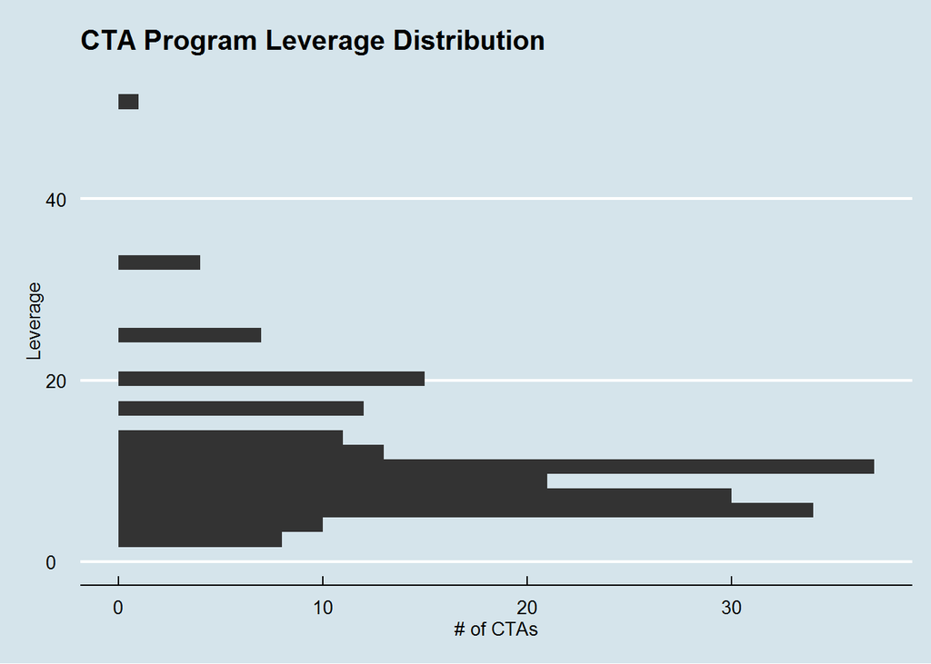

```r
# convert the margin-to-equity to numeric
marginToEquity<-(as.numeric(ctaMarginToEquity[,3]))
# convert the 'margin-to-equity' to leverage
leverage<-round(1/(marginToEquity/100),1)
# find the min leverage
minLeverage<-min(leverage,na.rm=TRUE)
# find the max leverage
maxLeverage<-max(leverage,na.rm=TRUE)
# create x
xLeverage<-seq(from=1,to=maxLeverage,by=1)
# find the frequency of different leverages
leverageFrequency<-tabulate(leverage)
# great the graph
leverageDf<-data.frame(leverage)
ggplot(leverageDf, aes(leverage)) + geom_bar() + coord_flip()+
  ggtitle('CTA Program Leverage Distribution')+xlab('Leverage')+ylab('# of CTAs')+theme_economist()+
  scale_colour_economist()
```

We extract the returns for a single managed futures program as follows:

```r
fetchMonthlyReturnsForCtaByProgramId <- function (dbHandle,programId){
  query<-paste0("SELECT eom_date,monthly_return FROM cta_monthly_returns ",
    "WHERE program_id=",programId)
  ctaReturns<-dbGetQuery(dbHandle,query)
  eomDate<-as.POSIXct(ctaReturns[,1])
  monthlyReturn<-ctaReturns[,2]/100
  ctaReturn<-data.frame(eomDate,monthlyReturn,stringsAsFactors=FALSE)
  ctaReturn
  }
```

We find all programs that existed prior to 2005-01-01.

```r
minDate<-"2005-01-01"
query<-paste0("SELECT DISTINCT cta_name,program_name,program_id,MIN(eom_date) AS minDate ",
  "FROM altegris.cta_monthly_returns WHERE eom_date<'",
  minDate,"' GROUP BY program_id ORDER BY cta_name;")
ctaList<-dbGetQuery(dbHandle,query)
programIds<-ctaList['program_id']
ctaNames<-ctaList['cta_name']
ctaPrograms<-ctaList['program_name']
# remove some of the detail from the program name to make names shorter
ctaPrograms[,1]<-gsub('*QEP*','',ctaPrograms[,1])
ctaPrograms[,1]<-gsub('*FRN*','',ctaPrograms[,1])
ctaPrograms[,1]<-gsub('\\**','',ctaPrograms[,1])
ctaPrograms[,1]<-gsub('*PROP*','',ctaPrograms[,1])
ctaPrograms[,1]<-gsub('*Program*','',ctaPrograms[,1])
```

We iterate over each program with historical data available prior to 2005-01-01 and extract the return data, adding each CTA program return stream to a group object.

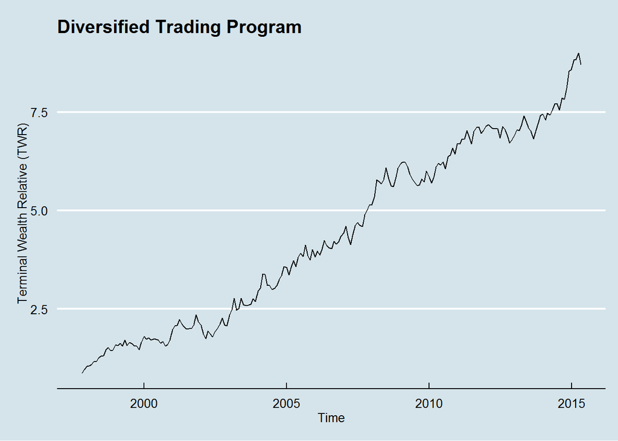

```r
# create the xts object to hold the group data
groupData <- xts()

for (programIndex in 1:dim(programIds)[1]){
  # get the program ID
  programId<-programIds[programIndex,1]
  # get the CTA name
  ctaName<-ctaList[programIndex,2]
  # fetch the program returns
  ctaReturn<-fetchMonthlyReturnsForCtaByProgramId(dbHandle,programId)
  dataObject<-xts(ctaReturn[,2],order.by=as.POSIXct(ctaReturn[,1],format='%Y-%m-%d'))
  recentData<-last(dataObject,'10 year')
  df<-data.frame(date=index(recentData),coredata(recentData))
  # create the individual graph
  p1 <- ggplot(ctaReturn, aes(x=eomDate, y=cumprod(1+monthlyReturn))) + geom_line() +
    ggtitle(ctaName)+xlab('Time')+ylab('Terminal Wealth Relative (TWR)')+theme_economist()+
    scale_colour_economist()
  # label the return data with the program ID
  colnames(recentData)<-programId
  # add the individual progrma data to the group
  groupData <- merge(groupData, recentData)
}
groupDataDimension<-dim(groupData)
print(p1)
```

We extract 112 months of CTA program return data for 76 distinct managed futures programs.

Our data includes most of the managers with the most impressive track records.

Sample of 10 of the 76 Programs

|  | cta_name | program_name | minDate |
| --- | --- | --- | --- |
| 8 | Campbell & Company, LP | Campbell Managed Futures | 1983-04-30 |
| 1 | Abraham Trading Company | Abraham Diversified Program | 1990-01-31 |
| 9 | Chesapeake Capital Corporation | Diversified Program *QEP* | 1990-01-31 |
| 22 | DUNN Capital Management, Inc. | World Monetary and Agriculture (WMA) Program *QEP* | 1990-01-31 |
| 26 | EMC Capital Advisors LLC | Classic Program *QEP* | 1990-01-31 |
| 34 | Hawksbill Capital Management | Global Diversified Program *QEP* | 1990-01-31 |
| 43 | Mark J. Walsh & Company | Standard Program | 1990-01-31 |
| 44 | Michael J. Frischmeyer, CTA | Michael J. Frischmeyer, CTA *CLSD* | 1990-01-31 |
| 45 | Millburn Corporation | Diversified Program | 1990-01-31 |
| 57 | Rabar Market Research, Inc. | Diversified Program *QEP* | 1990-01-31 |

## Data Cleaning

Data cleaning of the majority of the collected data pertaining to manager and program information was beyond the scope of this project and as a result, none of this data was used in the modeling sector of the paper.

The manager and program information collected is somewhat unstructured and visual inspection of the managed futures website reveals many reporting inconsistencies across managers. Our quick exploratory analysis confirms that data is reported somewhat inconsistently by CTAs. In particular, there appears to be very little validation of the manager and program information submitted by CTAs. As a result, this part of the collected data set requires a lot of cleaning and standardization before it can be used effectively in our modeling.

In this section we provide a brief example of the types of inconsistencies in the available program and manager data.

We extract the information about the geographical region of each manager as follows:

```r
# create the query
query<-paste0("SELECT DISTINCT column_value,COUNT(column_value) ",
  "FROM altegris.cta_program_info WHERE column_type = 'address' ",
  "AND column_name='Country' GROUP BY column_value  ORDER BY ",
"column_value;")
# extract the data
ctaCountry<-dbGetQuery(dbHandle,query)
# create the table
colnames(ctaCountry)<-c('Country','# of Programs')
knitr::kable(ctaCountry,caption='Programs By Country - Raw')
```

Programs By Country - Raw

| Country | # of Programs |
| --- | --- |
|  | 4 |
| Austria | 2 |
| Bahamas | 1 |
| Canada | 6 |
| Channel Islands | 1 |
| Cyprus | 1 |
| Finland | 4 |
| France | 2 |
| Germany | 1 |
| Hong Kong | 1 |
| Israel | 1 |
| Korea | 1 |
| Liechtenstein | 1 |
| Macedonia | 1 |
| Netherlands | 2 |
| Singapore | 1 |
| Spain | 2 |
| St. Croix USVI | 1 |
| Switzerland | 6 |
| UK | 1 |
| United Kingdom | 16 |
| United Kingdon | 3 |
| United States | 35 |
| US | 1 |
| USA | 111 |

Spelling errors and single countries coded with multiple names (i.e., United Kingdom, United Kingdon, or UK for instance) are clear.

We can clean up the data as follows:

```r
# replace empty with Unreported
ctaCountry[ctaCountry[,1]=='',1]<-'Unreported'
# reclassify US Virgin Islands as United States
ctaCountry[,1]<-gsub('St. Croix USVI','United States',ctaCountry[,1])
# we clean up the US entries
ctaCountry[,1]<-gsub('USA','United States',ctaCountry[,1])
ctaCountry[,1]<-gsub('US','United States',ctaCountry[,1])
# we clean up the UK entries
ctaCountry[,1]<-gsub('UK','United Kingdom',ctaCountry[,1])
ctaCountry[,1]<-gsub('United Kingdon','United Kingdom',ctaCountry[,1])
# create the country factor
countryFactor <- factor(ctaCountry[,1])
# redo the counts by country
cleanTable<-aggregate(x=ctaCountry[,2],by=list(countryFactor),FUN="sum")
# compute the percent by region
countryPercent<-round(cleanTable[,2]/sum(cleanTable[,2]),4)
# add row names
rownames(cleanTable)<-cleanTable[,1]
# create the table
cleanTable<-cbind(cleanTable,countryPercent*100)
# remove country column

# label the columns
colnames(cleanTable)<-c('Country','# of Programs','% of Programs')
# create the sort index
sortIndex<-sort.int(cleanTable[,2],index.return=TRUE,decreasing=TRUE)
# write the clean table
knitr::kable(cleanTable[sortIndex$ix,2:3],caption='Programs By Country - Cleaned')
```

Programs By Country - Cleaned

|  | # of Programs | % of Programs |
| --- | --- | --- |
| United States | 148 | 71.84 |
| United Kingdom | 20 | 9.71 |
| Canada | 6 | 2.91 |
| Switzerland | 6 | 2.91 |
| Finland | 4 | 1.94 |
| Unreported | 4 | 1.94 |
| Austria | 2 | 0.97 |
| France | 2 | 0.97 |
| Netherlands | 2 | 0.97 |
| Spain | 2 | 0.97 |
| Bahamas | 1 | 0.49 |
| Channel Islands | 1 | 0.49 |
| Cyprus | 1 | 0.49 |
| Germany | 1 | 0.49 |
| Hong Kong | 1 | 0.49 |
| Israel | 1 | 0.49 |
| Korea | 1 | 0.49 |
| Liechtenstein | 1 | 0.49 |
| Macedonia | 1 | 0.49 |
| Singapore | 1 | 0.49 |

Now we can see that 71.84% of the reporting managed futures programs are operated out of the United States and 9.71% are operated out of the United Kingdom. The vast majority of programs are operated out of these two regions (81.55%). It is also notable that 1.94% of managers do not provide information about their geographical location.

```r
# disconnect from the 'altegris' database
dbDisconnect(dbHandle)
```

```
## [1] TRUE
```

# Modeling

In the previous section, we provided an overview of the process used to obtain the monthly returns for all distinct CTA programs available in the Altegris managed futures database. In this section we first provide a brief overview of the theory underlying our simple factor model of managed futures program returns. We then build and use a factor model to create sensitivities that map the proportion of total variance in the investment universe to portfolio variation. This sensitivity allows us to monitor the time-varying proportion of variance explained by the first few statistical factors and instantly convert these measures of market state into portfolio variability.

## Theory

In this section, we provide a brief overview the theoretical underpinnings of the modeling approach employed in our application. In particular, we provide an outline of the eigen-decomposition underlying the statistical factor analysis and outline an approach for determining how many investment components contribute to each statistical factor. We conclude this section by introducing an approach for computing factor sensitivities.

#### Standardized Returns

Standardization rescales a variable while preserving its order.

We denote the monthly return of the $i^{th}$ investment for the $m^{th}$ month as $r_{i,m}$ and define the standardized return as:

$\hat{r}_{i,m}=\frac{\left( r_{i,m}-\bar{r}_{i,M}\right)}{\sigma(r_{i,M})}$

Where

$\hat{r}_{i,m}$ is the standardized return of the $i^{th}$ investment for the $m^{th}$ month using data over the time interval one to $M$

$r_{i,m}$ is the observed return of the $i^{th}$ investment for the $m^{th}$ month

$\bar{r}_{i,M}=\frac{1}{M}\sum_{m=1}^{M}\left(\hat{r}_{m}\right)$ is the mean of the return stream of the $i^{th}$ investment over the time interval one to $M$

$\sigma(r_{i,M})=$ is the standard deviation of the returns for the $i^{th}$ investment over the time interval one to $M$

#### Correlations

We represent the standardized returns as an $I$ x $M$ matrix $\hat{R}$ with an empirical correlation matrix $C$ defined as:

$C = \frac{1}{M}\hat{R}\hat{R}^{T}$

Where

$T$ denotes the matrix transform

The correlation matrix ($C$) of returns ($\hat{R}$) and the covariance matrix ($\Sigma_{\hat{R}}$) of standardized returns ($\hat{R}$) are identical.

### Principal Component Analysis (PCA)

The objective of principal component analysis (PCA) is to find a linear transformation $\Omega$ that maps a set of observed variables $\hat{R}$ into a set of uncorrelated variables $F$. We define the $I$ x $M$ statistical factor matrix as

$F = \Omega\hat{R}$

Where each row $f_{k}$ ($k = 1, \dots ,N$) corresponds to a factor $F$ of $\hat{R}$ and the transformation matrix $\Omega$ has elements $\omega_{k,i}$. The first row of $\omega_{1}$ (which contains the first set of factor coefficients or ‘loadings’) is chosen such that the first factor ($f_{1}$) is aligned with the direction of maximal variance in the $I$-dimensional space defined by $\hat{R}$. Each subsequent factor ($f_{k}$) accounts for as much of the remaining variance of the standardized returns $\hat{R}$ as possible, subject to the constraint that the $\omega_{k}$ are mutually orthogonal. The vectors $\omega_{k}$ are further constrained by requiring that $\omega_{k}\omega_{k}^{T}=1$ for all $k$.

The correlation matrix $C$ is an $I$ x $I$ diagonalizable symmetric matrix that can be written in the form

$C = \frac{1}{M}EDE^{T}$

Where $D$ is a diagonal matrix of eigenvalues $d$ and $E$ is an orthogonal matrix of the corresponding eigenvectors.

The eigenvectors of the correlation matrix $C$ correspond to the directions of maximal variance such that $\Omega=E^{T}$. Statistical factors / principal components $F$ are found using the diagonalization above.

If the sign of every coefficient in a statistical factor $f_{k}$ is reversed, neither the variance of $f_{k}$ nor the orthogonality of $\omega$ with respect to each of the other eigenvectors changes. For this reason, the signs of factors (PCs) are arbitrary. This feature of PCA can be problematic when we are interested in the temporal evolution of factors.

#### Proportion of Variance

The covariance matrix $\Sigma_{F}$ for the statistical factor matrix $F$ can be written as:

$\Sigma_{F}=\frac{1}{M}FF^{T}=\frac{1}{M}\Omega\hat{R}\hat{R}^{T} \Omega^{T} = D$

Where $D$ is the diagonal matrix of eigenvalues $d$.

The total variance of the standardized returns $\hat{R}$ for the $I$ investments is then

$\sum_{i=1}^{I}\sigma^{2}(\hat{r}_{i})=tr(\Sigma_{\hat{R}})=\sum_{i=1}^{I}d_{i}=\sum_{i=1}^{N}\sigma^{2}(f_{i})=tr(D)=I$

Where $\Sigma_{\hat{R}}$ is the covariance matrix for $\hat{R}$

$\sigma^{2}(\hat{r_{i}})=1$ is the variance of the vector $\hat{r_{i}}$ of standardized returns for investment $i$.

The proportion of the total variance in $\hat{R}$ explained by the $k^{th}$ factor is then

$\frac{\sigma^{2}(f_{k})}{\Sigma_{i=1}^{I}\sigma^{2}(\hat{r_{i}})}=\frac{d_{k}}{\Sigma_{i=1}^{I}d_{k}}=\frac{d_{k}}{I}$

The proportion of the variance from the $k^{th}$ factor is equal to the ratio of the $k^{th}$ largest eigenvalue $d_{k}$ to the number of investments $I$.

#### Number of Significant Components

To determine how many statistical factors are needed to describe the correlations between investments, many methods have been proposed. There is no widespread agreement on an optimal approach. In this paper we focus on the first factor where we are able to find a clear economic interpretation.

#### Significant Statistical Factor Coefficients

An increase in the variance associated with a factor can be the result of increases in the correlations among only a few investment programs (which then have large factor coefficients) or an effect in which many investment programs make significant contributions to the factor. Since the two types of changes have very different implications for portfolio management, this distinction is critically important. It becomes much more difficult to reduce risk by diversifying across different investments when correlations between all investments increase. In contrast, increases in correlations within an investment type when correlations between investment types are not increasing have a less significant impact on diversification.

##### Inverse Participation Ratio (IPR)

The inverse participation ratio $IPR_{k}$ of the $k^{th}$ factor $\omega_{k}$ is defined as:

$IPR_{k}=\sum_{i=1}^{I}\left( \omega_{k,i}\right)^{4}$

The IPR quantifies the reciprocal of the number of elements that make a significant contribution to each eigenvector.

The behavior of the IPR is bounded by two cases:

[1] An eigenvector with identical contributions $\omega_{k,i}=\frac{1}{\sqrt{I}}$ from all $I$ investments has $IPR_{k}=\frac{1}{I}$

[2] An eigenvector with a single factor $\omega_{k,i}=1$ and remaining factors equal to zero has $IPR=1$

The inverse of the IPR - the so-called participation ratio - provides a more intuitive measure of the significance of a given factor as a large $PR$ indicates that many investments contribute to the factor, while a small $PR$ signals that few investments contribute to the factor:

$PR = \frac{1}{IPR_{k}}$

The participation ratio quantifies the number of eigenvector (loading) components that participate in a factor and provides a measure of concentration.

The bigger a $PR$ is, the more participants the statistical factor has, the more uniformly distributed the participation is, and the more correlations are driven by the statistical factor.

Participation ratios facilitate the identification of statistical factors that represent macroeconomic scenarios, namely those with with many participants. They also help us identify factors that represent micro-economic scenarios, namely factors with few participants.

### Portfolio Factor Sensitivities and Coherent Scenario Analysis

We can use our factor model to determine the impact of an increase in the proportion of variance described by any given statistical factor on our correlation matrix. By perturbing the eigenvalues up and down and applying the appropriate re-normalizations we create changes in the correlations driven by a common factor.

The following three functions are used to implement the sensitivity analysis in the application section of the paper.

```r
perturbCorrelation<-function (shockFactor,factorIndex,eigenvalues,eigenvectors){
  # create the hash to store the results
  scenario<-hash()
  scenarioEigenvalues <- eigenvalues
  scenarioEigenvalues[factorIndex] <- eigenvalues[factorIndex] * shockFactor
  C1 <- eigenvectors %*% diag(scenarioEigenvalues) %*% t(eigenvectors)
  # extract the variance
  V <- diag(1/sqrt(C1))
  # normalize the correlation matrix
  C2 <- diag(V) %*% C1 %*% diag(V)
  # eigen decomposition
  scenarioDecomposition=eigen(C2)
  # extract the stressed eigenvalues
  eigenvaluesF=scenarioDecomposition$values
  # extract the stressed eigenvector
  eigenvectorF=scenarioDecomposition$vectors
  # number of factors
  numberOfFactors<-sum(eigenvaluesF)
  # compute the proportion of variance
  scenarioProportionOfVariance<-eigenvaluesF/numberOfFactors
  # store the correlation matrix
  scenario['correlation']<-C2
  # store the proportion of variance
  scenario['proportionOfVariance']<-scenarioProportionOfVariance
  # return the scenario
  scenario
}
```

```r
perturbFactorCorrelation <- function (factorIndex,eigenvalues,eigenvectors){
  # create the hash
  scenarios<-hash()
  # create shock scenarios
  shockFactors<-seq(from=0.2,to=5,by=0.2)

  # iterate over shock factors
  for (shockIndex in seq_along(shockFactors)){
    # extract the shock
    shockFactor<-shockFactors[shockIndex]
    # increase the importance of the factorIndex factor
    scenario<-perturbCorrelation(shockFactor,factorIndex,eigenvalues,eigenvectors)
    # store the correlation
    scenarios[paste0('scenario_',shockIndex)]<-scenario
  }
  # return scenarios
  scenarios
}
```

```r
factorBasedCorrelationSensitivity<-function (numberOfFactors,C){
  # find the number of rows and columns
  dimension<-dim(C)
  # create the storage matrix
  sensitivity<-matrix(0,numberOfFactors,dimension[2])
  # compute the eigendecomposition
  decomposition=eigen(C)
  # extract eigenvalues
  eigenvalues=decomposition$values
  # extract eigenvectors
  eigenvectors=decomposition$vectors
  # find the proportion of variance
  proportionOfVariance=eigenvalues/length(eigenvalues)
  # find the explained variance
  explainedVariance=cumsum(proportionOfVariance)
  # create hash
  scenariosByFactor<-hash()

  # iterate over each factor
  for (factorIndex in 1:numberOfFactors){
    # perturb the factor
    scenarios<-perturbFactorCorrelation(factorIndex,eigenvalues,eigenvectors)
    scenariosByFactor[paste0('factor_',factorIndex)]<-scenarios
    #
    scenarioIndices<-sort(as.numeric(gsub('scenario_','',
      names(scenariosByFactor[paste0('factor_',factorIndex)]))))
    }
  scenariosByFactor
}
```

## Applicaton

In this section we apply the theory outlined in the above section. In particular, we build a simple factor model of managed futures program returns and use it to create sensitivities that map the proportion of total variance in the investment universe to portfolio variation. This sensitivity allows us to monitor the time-varying proportion of variance explained by the first few statistical factors and instantly convert these measures of market state into portfolio variability. This is particularly useful during times of crisis when the importance of the first few factors increase significantly.

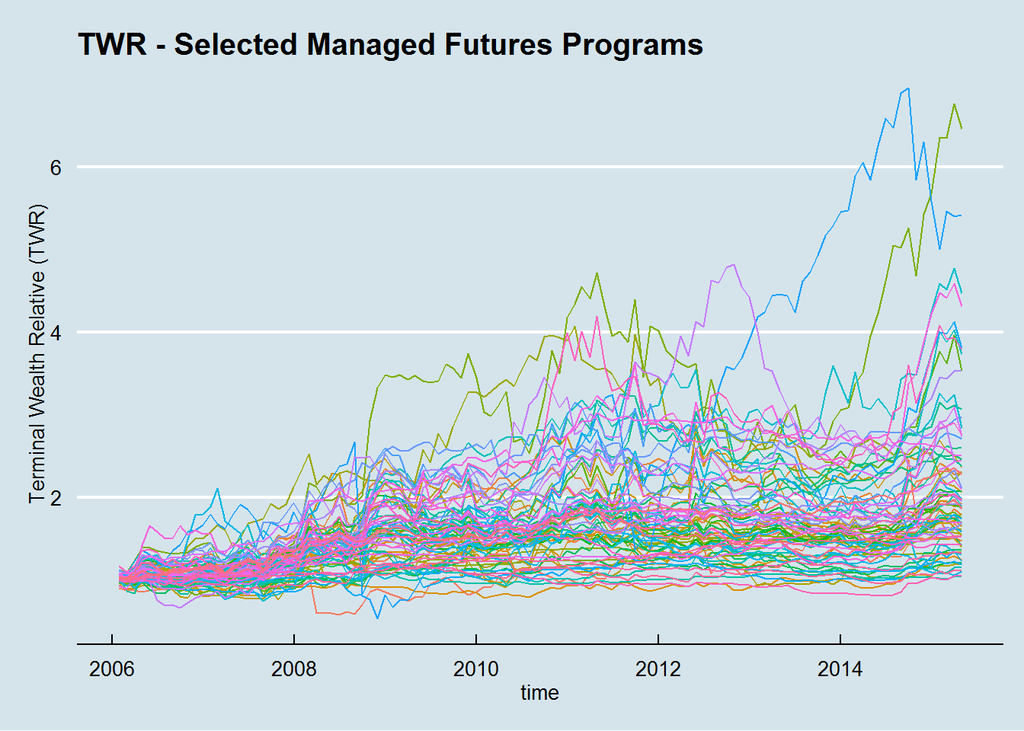

### Data Preprocessing

Prior to any modeling, we standardize the managed futures program returns.

We compute then create a heatmap of the correlation.

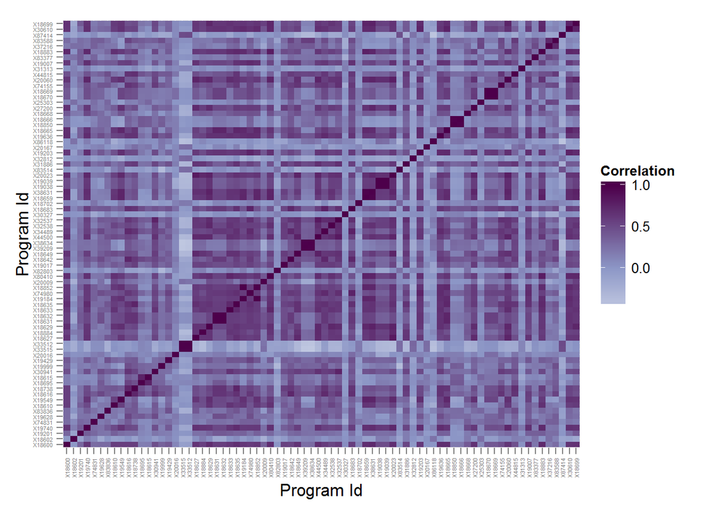

### Statistical Factor Analysis

We now decompose the correlation matrix into statistical factors.

The top 5 factors explain a very significant proportion of the total variance.

| Factors | Proportion of Variance | Cumulative Proportion of Variance |
| --- | --- | --- |
| Factor 1 | 36.8 | 36.8 |
| Factor 2 | 8.8 | 45.7 |
| Factor 3 | 6.5 | 52.1 |
| Factor 4 | 4.0 | 56.1 |
| Factor 5 | 3.6 | 59.8 |
| Factor 6 | 3.0 | 62.8 |
| Factor 7 | 2.5 | 65.3 |
| Factor 8 | 2.2 | 67.6 |
| Factor 9 | 2.2 | 69.8 |
| Factor 10 | 2.0 | 71.8 |

The first statistical factor accounts for 37% of the variation of the systems. Indeed the first factor is the most significant by far. The second factor accounts for another 9% of the variation, and the third component accounts for 6% more. Indeed, the first three factors together account for 52% of the variation. The first 10 factors account for 72% proportion of the variation in the system. By focusing on just three factors we can understand a very significant proportion of the total variation in the managed futures universe under study.

The ten smallest factor loadings are:

Smallest Factor 1 Loadings

|  | Manager Name | Program Name | Factor 1 |
| --- | --- | --- | --- |
| 18 | Doherty Advisors, LLC | Relative Value Volatility 2X | -0.0434 |
| 19 | Doherty Advisors, LLC | Relative Value Volatility 1X | -0.0410 |
| 74 | Warrington Asset Management Corp. | Strategic Fund | -0.0228 |
| 52 | Paskewitz Asset Management, LLC | Contrarian 3X Stock Index | -0.0209 |
| 50 | Omni Trading, LLC | S&P 500 Option Overwriting | -0.0039 |
| 54 | Quantitative Investment Management, LLC | Global | 0.0023 |
| 42 | Kinkopf Capital Management, LLC | Kinkopf S&P | 0.0034 |
| 68 | Systematic Alpha Management LLC | Systematic Alpha Futures | 0.0044 |
| 2 | AgTech Trading Company | Ag Trading | 0.0052 |
| 32 | Goldman Management, Inc. | Goldman Management Stock Index Futures | 0.0079 |

The ten largest factor loadings are:

Largest Factor 1 Loadings

|  | Manager Name | Program Name | Factor 1 |
| --- | --- | --- | --- |
| 75 | Welton Investment Partners LLC | Global Directional Portfolio | 0.1514 |
| 41 | Kelly Angle Inc. | Genesis | 0.1516 |
| 66 | SMN Investment Services GmbH | Diversified Futures | 0.1522 |
| 28 | Estlander & Partners Ltd. | Alpha Trend | 0.1522 |
| 22 | DUNN Capital Management, Inc. | World Monetary and Agriculture (WMA) | 0.1525 |
| 1 | Abraham Trading Company | Abraham Diversified | 0.1530 |
| 49 | Mulvaney Capital Management Ltd | Global Diversified | 0.1550 |
| 38 | ISAM - International Standard Asset Management | Systematic | 0.1563 |
| 56 | Quest Partners LLC | AlphaQuest Original (AQO) | 0.1586 |
| 26 | EMC Capital Advisors LLC | Classic | 0.1603 |

The first factor can be thus thought of as a ‘long directional volatility’ factor.

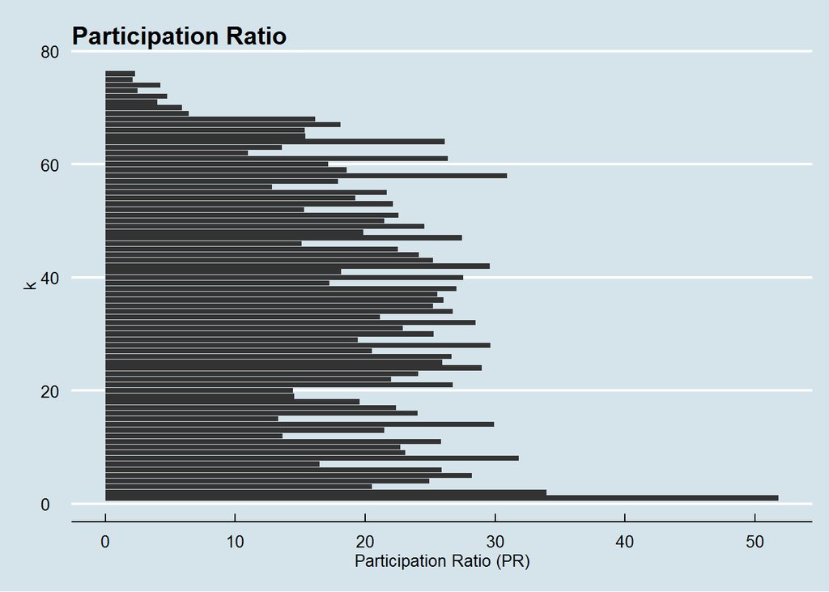

Using the participation ratio defined in the previous section, we see that 52 components make significant contributions to the first factor. This is in strong contrast to the other factors where the number of components making significant contributions is between 2 and 34.

Although more examination of the factors would be required to get an deeper intuitive sense of the *meaning* of the factors, we proceed to illustrating how our simple statistical factor model can be used to create sensitivities.

#### Determining the Impact of Factors on Portfolio Variability

We can perturb the importance of the first factor up and down and use our equation for portfolio standard deviation to determine the impact on a portfolio with equal allocations to our 76 managed futures programs.

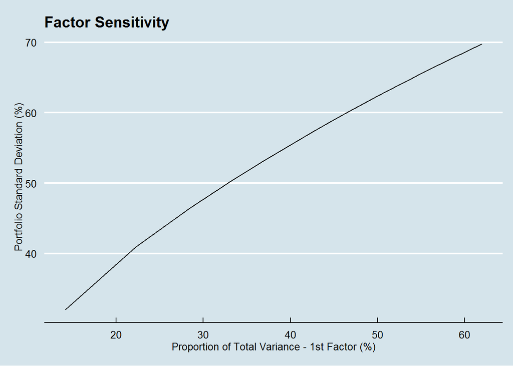

As the proportion of the portfolio variance explained by the first factor increases, the portfolio variance increases. Using this sensitivity measure, we can track the current proportion of variance explained by the first factor and instantly know the impact on the variation of portfolio returns.

We can visualize a scenario where the importance of the first factor falls to extremes:

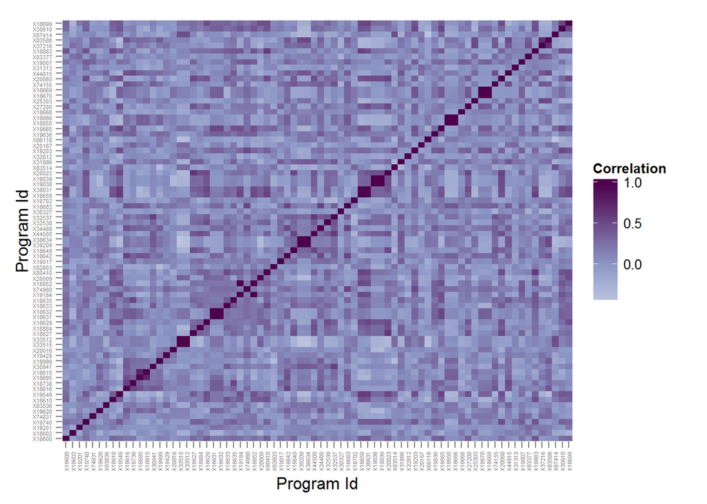

We can visualize a scenario where the importance of the first factor rises to extremes:

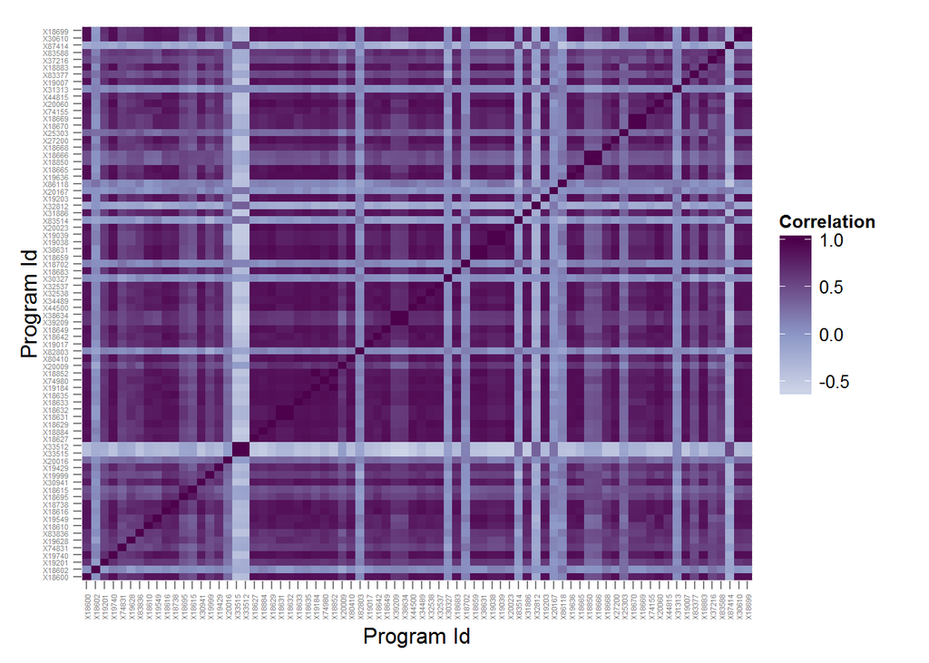

# Conclusions

Our factor analysis revealed a very significant proportion of the total variance of the modeled managed futures universe can be captured by a single statistical factor. This factor corresponds to a very intuitive scenario. The sensitivity analysis developed - given the intuitive interpretation of the first factor - can be used to better understand variation in the managed futures universe and can be used to identify programs that provide better diversification.

# References

[1] C. Bacon [2008], Practical Portfolio Performance Measurement and Attribution, $2^{nd}$ Ed, John Wiley & Sons, Inc.

[2] D. J. Fenn, N. F. Johnson, N. S. Jones, M. McDonald, M. A. Porter, S. Williams [2011], Temporal evolution of financial-market correlations, Physical Review E 84, 026109

[3] F. J. Fabozzi, S. M. Focardi, P. N. Kolm [2010], Quantitative Equity Investing: Techniques and Strategies (Frank J. Fabozzi Series), John Wiley & Sons, Inc.

[4] N. Fenton, M. Neil [2013], Risk Assessment and Decision Analysis With Bayesian Networks, CRC Press

[5] D. Koller, N. Friedman [2009], Probabilistic graphical models: principles and techniques, MIT press.

[6] A. Golub and Z. Guo [2012], Correlation Stress Tests Under the Random Matrix Theory: An Empirical Implementation to the Chinese Market

[7] A Meucci [2009], Risk and Asset Allocation, $1^{st}$ Ed, Springer Berlin Heidelberg

[8] R. Rebonato [2010], Plight of the Fortune Tellers: Why We Need to Manage Financial Risk Differently, Princeton University Press

[9] R. Rebonato [2010], Coherent Stress Testing: A Bayesian Approach to the Analysis of Financial Stress , John Wiley & Sons, Inc.

[10] R. Rebonato and A. Denev [2014], Portfolio Management Under Stress: A Bayesian-net Approach to Coherent Asset Allocation, Cambridge University Press

[11] D. Skillicorn [2007], Understanding Complex Datasets: Data Mining with Matrix Decompositions, Chapman and Hall/CRC

[12] R. Vince [2007], The Handbook of Portfolio Mathematics: Formulas for Optimal Allocation and Leverage, John Wiley & Sons, Inc.

# Appendix A: GitHub Repository

All of the R code used to produce this paper can be found in the following github repository:

https://github.com/dgn2/managed_futures

The github repository also includes the .Rmd file used to generate the .pdf working paper file and includes code to:

- extract CTA manager, program, and monthly return data from the Altegris managed futures website
- create a MySQL database with tables to store extracted CTA manager, program, and monthly return data
- load CTA manager, program, and monthly return data to the MySQL database
- conduct limited exploratory analysis of the data
- conduct limited cleaning of the data used in subsequent statistical modeling
- estimate statistical factors based on the monthly returns of a select set of CTA programs
- compute sensitivities

# Apprendix B: Fundamental Laws of Investing

## Importance of Capital Preservation

The amount to recover from a loss increases geometrically with the magnitude of the loss.

$G = \left(\frac{1}{1-L}\right)-1$

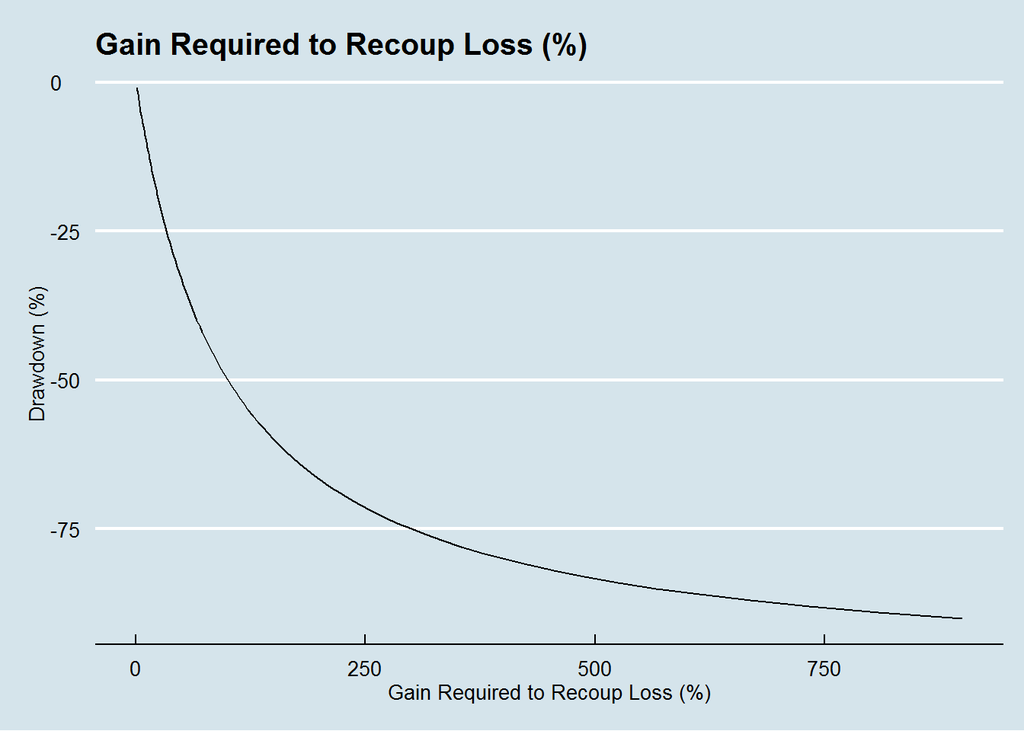

Gain Required to Recoup Loss (%)

|  | Gain Required to Recoup Loss (%) | Drawdown (%) |
| --- | --- | --- |
| 5 | 5.26 | -5 |
| 10 | 11.11 | -10 |
| 15 | 17.65 | -15 |
| 20 | 25.00 | -20 |
| 30 | 42.86 | -30 |
| 40 | 66.67 | -40 |
| 50 | 100.00 | -50 |
| 60 | 150.00 | -60 |
| 70 | 233.33 | -70 |

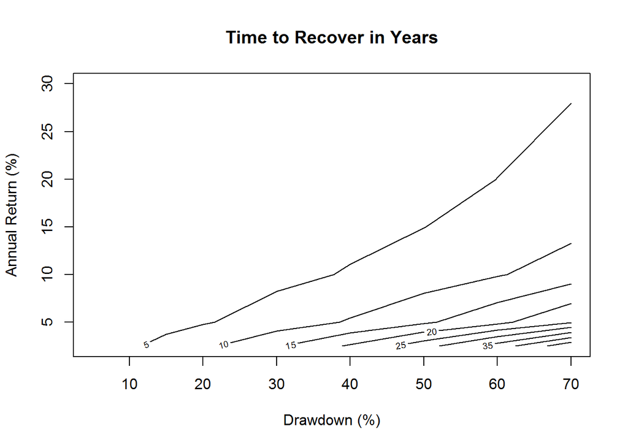

Time to Recover From Drawdown (Years)

|  | 2.5 | 5 | 10 | 15 | 20 | 30 |
| --- | --- | --- | --- | --- | --- | --- |
| 5 | 2.08 | 1.05 | 0.54 | 0.37 | 0.28 | 0.20 |
| 10 | 4.27 | 2.16 | 1.11 | 0.75 | 0.58 | 0.40 |
| 15 | 6.58 | 3.33 | 1.71 | 1.16 | 0.89 | 0.62 |
| 20 | 9.04 | 4.57 | 2.34 | 1.60 | 1.22 | 0.85 |
| 30 | 14.44 | 7.31 | 3.74 | 2.55 | 1.96 | 1.36 |
| 40 | 20.69 | 10.47 | 5.36 | 3.65 | 2.80 | 1.95 |
| 50 | 28.07 | 14.21 | 7.27 | 4.96 | 3.80 | 2.64 |
| 60 | 37.11 | 18.78 | 9.61 | 6.56 | 5.03 | 3.49 |
| 70 | 48.76 | 24.68 | 12.63 | 8.61 | 6.60 | 4.59 |